# Accessing Twitter using Rtweets Package

Peter McNamara

27 March 2019

# Introduction

This vignette explains the steps in using the functions provided by the **rtweet** package to access tweets from Twitter. Twitter provide REST APIs for accessing tweets and user data, which the rtweet functions sit over.

There are several pre-R steps to perform to access tweets. This [blog](https://towardsdatascience.com/access-data-from-twitter-api-using-r-and-or-python-b8ac342d3efe) does a good explanation of these steps and in summary:

1. First, you must have a twitter account
2. Then, apply for twitter developer access. This entails setting up an app and receiving confirmation from Twitter.
3. After this, a twitter app can be created, and importantly **consumer** and **access** keys are created. These are then used for authorisation when connecting to twitter from R using the REST APIs.

To access Twitter, the first step is to install the rtweet package and load the library. Some other packages I use along the way are also loaded here.

```r
## install rtweet from CRAN
install.packages("rtweet")
install.packages("qdapRegex")
```

```r
## load rtweet package
library(rtweet)
library(qdapRegex)
library(plyr)
library(tidyverse)
library(tm)
library(ggplot2)
library(wordcloud)
```

# Authorisation

Now, to access twitter, an authorisation token must be created. The **create_token** function does this. Note that if only the consumer keys are sent (or an access token was not created in the twitter app), then a web-browser will popup to complete access to twitter asking for username/password. Also note in the code snippet, you will need to add your own credentials as these are private per user.

```r
# Change the next four lines based on your own consumer_key, consume_secret, access_token, and access_secret.
consumer_key <- "Copy your Consumer Key for the application here"
consumer_secret <- "Copy your Consumer Secret for the application here"
access_token <- "Copy your Access Token for the application here"
access_secret <- "Copy your Access Secret for the application here"

## authenticate via access token
token <- create_token(
  app = "Movie Trends - UTS",
  consumer_key = consumer_key,
  consumer_secret = consumer_secret,
  access_token = access_token,
  access_secret = access_secret)
```

# Searching For Tweets

After authentication is successful, I can search for tweets using the **search_tweets** function call. This must be passed a query string to search the text for and other useful parameters are:

[output not shown]

To get English tweets about the movie Captain Marvel using the hashtag **#captainmarvel**, the call would be as follows. Under the standard APIs only data from the last 6-9 days is returned. The tweets are put into a dataframe by default.

```r
numberOfTweets <- 15000
tweets_cm <- search_tweets('#captainmarvel', n = numberOfTweets, type = "recent", include_rts = FALSE, retryonratelimit = TRUE, lang='en')
```

```
## Searching for tweets...
```

```
## This may take a few seconds...
```

```
## Finished collecting tweets!
```

```r
nrow(tweets_cm)
```

```
## [1] 16068
```

If we look at the data frame returned, we can see there are 16068 returned tweets.

# Using the Data

## Plotting a Time Series

Now that we have a list of tweets, another useful function in the rtweet package is to plot the time series of the tweets we have just captured using **ts_plot**. This function takes a data frame and a time period to plot. Here, hours is the time period and shows how tweets follow a distinct pattern over the course of a day.

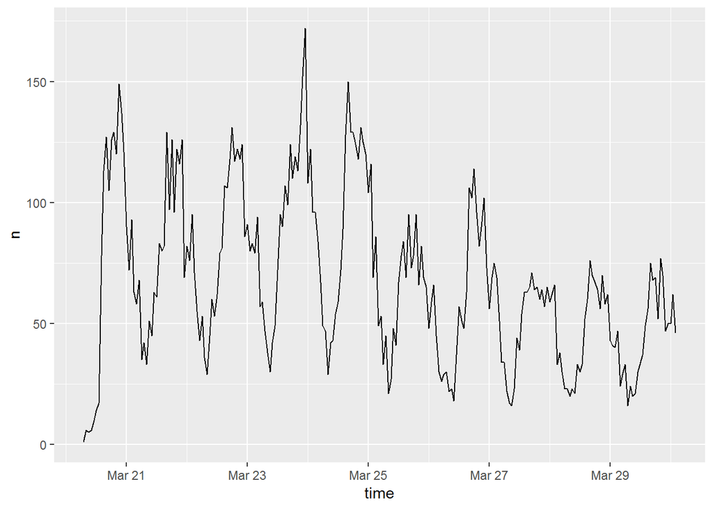

```r
ts_plot(tweets_cm, by = "hours")
```

**ts_data** builds the data behind this plot, having 1 row per time period and the number of tweets in that period. This can be useful for producing graphs using ggplot, so below we get the tweets for the movie **Green Book** and compare to **Captain Marvel** on the same graph. Marvel comics not only dominates the box office but also the twittersphere.

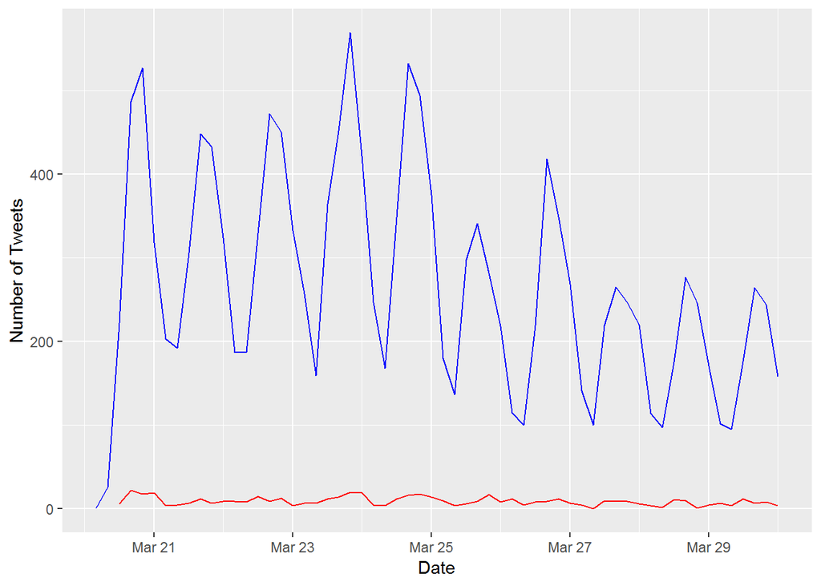

```r
tweets_gb <- search_tweets('#greenbook', n = numberOfTweets, type = "recent", include_rts = FALSE, retryonratelimit = TRUE, lang='en')

# compare over 4 hour periods
ts_cm <- ts_data(tweets_cm, by = "4 hours")
ts_gb <- ts_data(tweets_gb, by = "4 hours")

# Plot the 2 lines together.  since green book goes back further, filter green book data to start at the same time as Captain Marvel data
ggplot(data=ts_cm)  +
  geom_line(aes(x=time, y=n), color="Blue") +
  geom_line(data=filter(ts_gb, time >= min(ts_cm$time)), aes(x=time, y=n), color="Red") +
  labs(x = "Date", y = "Number of Tweets")
```

## Wordcloud

To end, the tweets can be loaded into a corpus (collection of documents), cleaned by removing urls, special characters, common words, punctuation and numbers and then use **wordcloud** to display the top 50 terms in the data. I have also removed ‘captainmarvel’ as this was the search term so will obviously be in each text.

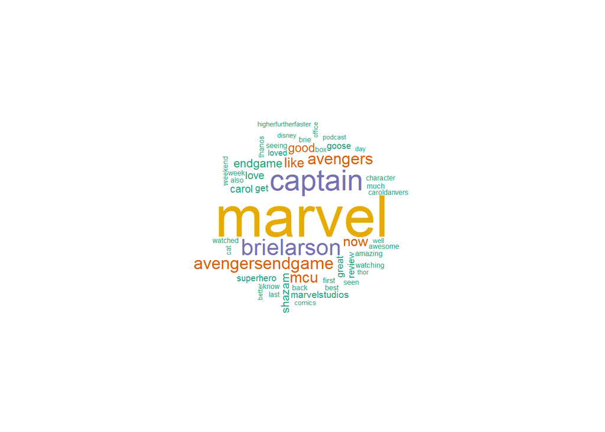

```r
#Remove characters functions
tweet.removeEmoji = function(x) gsub("\\p{So}|\\p{Cn}", "", x, perl = TRUE)
tweet.removeSpecialChar = function(x) gsub("[^[:alnum:]///' ]", "", x)
toSpace <- content_transformer(function(x, pattern) {return (gsub(pattern, " ", x))})

tweets_cm$text <- rm_url(tweets_cm$text)
tweets_cm$text <- rm_twitter_url(tweets_cm$text)
docs = Corpus(VectorSource(tweets_cm$text))

docs <- tm_map(docs, toSpace, "-")
docs <- tm_map(docs, toSpace, "`")
docs <- tm_map(docs, toSpace, ":")
docs <- tm_map(docs, removePunctuation)
docs = tm_map(docs, content_transformer(tweet.removeEmoji))
docs = tm_map(docs, content_transformer(tweet.removeSpecialChar))
docs <- tm_map(docs,content_transformer(tolower))
docs <- tm_map(docs, removeNumbers)
docs <- tm_map(docs, removeWords, stopwords("english"))
docs <- tm_map(docs, stripWhitespace)
docs <- tm_map(docs, removeWords, "captainmarvel")
docs <- tm_map(docs, removeWords, "rt")

# Extra stop words from analysing frequencies after doing stem and culling DTM
myStopwords <- c('movie', 'amp', 'saw', 'time', 'film', 'really', 'watch', 'today', 'dont',
                 'got', 'didnt', 'cant', 'can', 'will', 'finally', 'going',
                 'new', 'wait', 'think', 'just', 'see', 'one', 'movies', 'still')
docs <- tm_map(docs, removeWords, myStopwords)

# convert corpus to Document Term Matrix
dtm <-DocumentTermMatrix(docs)

# collapse matrix by summing over columns and then ordering by frequency
freq <- colSums(as.matrix(dtm))

# setting the same seed each time ensures consistent look across clouds
set.seed(10)
# wordCloud with colour for 50 words
par(mar = rep(0, 4))
wordcloud(names(freq),freq,max.words=50,colors=brewer.pal(6,"Dark2"),
          scale = c(4, 0.2),random.order=FALSE, rot.per=.15)
```

# References

- Galarnyk, M. (2018). “https://towardsdatascience.com/access-data-from-twitter-api-using-r-and-or-python-b8ac342d3efe.”
- Kearney, M. (2018). “Package rtweet” from https://cran.r-project.org/web/packages/rtweet/rtweet.pdf.